# Monthly Payment-Propensity Model Report

**Run month:** Oct · **Model:** logistic regression developed on July 2005 (2+ months behind), 9 payment-behaviour features, no age, sex, education or marital status · **Accounts scored:** 30,000

## 1. Status at a glance

| Check | Value | Status |
| --- | --- | --- |
| Score distribution (PSI vs. July) | 0.081 | stable |
| Repayment-status input (PSI vs. July) | 0.914 | investigate |
| Observed / expected | 1.29 | investigate |
| Ranking (AUC) | 0.742 | watch |

Thresholds: PSI below 0.10 stable, 0.10-0.25 watch, above 0.25 investigate; observed/expected outside 0.85-1.15 investigate.

## 2. Month by month

| Month | Label | Observed rate | Predicted rate | O/E | AUC | Defaults in riskiest 10% | Score PSI | Status PSI | Coded “1 month late” |
| --- | --- | --- | --- | --- | --- | --- | --- | --- | --- |
| Jul | 2+ months behind | 14.0% | 14.0% | 1.00 | 0.865 | 55.5% | 0.000 | 0.000 | 0.01% |
| Aug | 2+ months behind | 14.7% | 15.3% | 0.96 | 0.877 | 53.3% | 0.003 | 0.009 | 0.01% |
| Sep | 2+ months behind | 10.4% | 16.0% | 0.65 | 0.872 | 52.7% | 0.007 | 0.017 | 0.09% |
| Oct | default flag (issuer) | 22.1% | 17.1% | 1.29 | 0.742 | 30.8% | 0.081 | 0.914 | 12.29% |

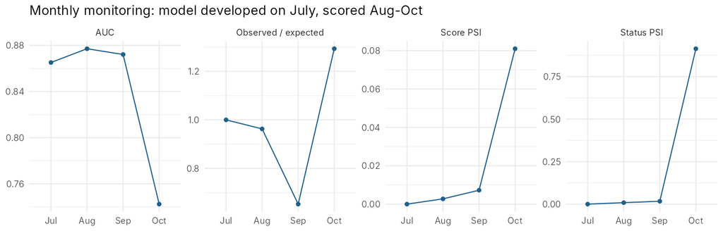

## 3. What changed

Accounts by raw repayment-status code and month (source data)

| status | Apr | May | Jun | Jul | Aug | Sep |
| --- | --- | --- | --- | --- | --- | --- |
| -2 | 4895 | 4546 | 4348 | 4085 | 3782 | 2759 |
| -1 | 5740 | 5539 | 5687 | 5938 | 6050 | 5686 |
| 0 | 16286 | 16947 | 16455 | 15764 | 15730 | 14737 |
| 1 | 0 | 0 | 2 | 4 | 28 | 3688 |
| 2 | 2766 | 2626 | 3159 | 3819 | 3927 | 2667 |
| 3 | 184 | 178 | 180 | 240 | 326 | 322 |
| 4 | 49 | 84 | 69 | 76 | 99 | 76 |
| 5 | 13 | 17 | 35 | 21 | 25 | 26 |
| 6 | 19 | 4 | 5 | 23 | 12 | 11 |
| 7 | 46 | 58 | 58 | 27 | 20 | 9 |
| 8 | 2 | 1 | 2 | 3 | 1 | 19 |

- **The score distribution never moved enough to raise a flag** (score PSI at most 0.081).
- **The inputs did.** The code for “1 month late” was used for 28 accounts in August and 3,688 in September, while the “2 months late” count fell. A jump that size in one month most likely reflects a change in how status was recorded, not in customer behaviour (to be confirmed with the data owner). It pushed the status-input PSI to 0.91.
- **September’s outcome label was affected first:** observed/expected fell to 0.65, because fewer accounts were coded “2+ months behind”.
- The model treats the new code as “1 month behind”. For the 3,688 October accounts carrying it, predicted default was 35.3% and observed 33.9%. That is close, but the code was never seen in development, so it is luck, not validation.
- October’s label is the issuer’s default flag rather than “2+ months behind”, so its observed/expected is not comparable with earlier months.

## 4. Actions

1. Confirm the status-code change with the data owner before the next run.
2. Refit on data after the change (the October-developed model reaches AUC 0.771 on held-out accounts).
3. Keep feature-level PSI in the report: score PSI alone would have passed this month.